# Микросимуляция

Finn the Human

# Введение

В курсе микроэкономики вы уже познакомились с базовой теорией производителя. Сегодня мы вспомним эту теорию и с её помощью займёмся симуляцией рыночного равновесия, а ещё посмотрим, как пользоваться R Notebook и некоторыми пакетами в R.

Писать мы будем в простом языке разметки markdown, который интегририрован в R и легко компилируется в html (и чуть сложнее — в pdf). Перейдём к следующему разделу и, чтобы выделить заголовок, поставим знак # (количество # соответствует уровню заголовка).

# Теория + LaTeX

Запишем функцию прибыли — разницу между выручкой и издержками.:
$$\pi = p \cdot y - w \cdot x,$$
где: * $\pi$ — это прибыль, * $p$ — цена продукции, * $w$ — цена фактора производства.

Решая задачу минимизации издержек при любом заданном выпуске, мы получаем функцию издержек $TC(y)$.

Можно записать прибыль в следующем виде:
$$\pi = p \cdot y - TC(y)$$
Издержки можно разложить на постоянные $FC$ (не зависят от объема выпуска) и переменные $VC$ (зависят от объёма выпуска):

$$TC(y) = FC + VC(y)$$
.

Тогда, решая задачу максимизации прибыли фирмы (возьмём производную по $y$), получим в краткосрочном периоде:
$$MC = p ,\text{если } p \geq AVC,$$
а в долгосрочном периоде:
$$MC = p,\text{если } p \geq AC.$$

## Симуляция

Вспомнили теорию — реализуем её в R. Симулируем рынок мёда и попробуем спрогнозировать параметры равновесия на рынке: * объём производства $q$, * количество фирм $n$. В качестве бонуса посмотрим, что произойдёт, если появится налог на продажу мёда.

Чтобы сделать хороший прогноз, было бы неплохо владеть аппаратом матстатистики, но есть и более простой способ — надо тупо прогнать одну и ту же модель, случайным образом меняя параметры, много-много раз и посмотреть, что получится. Это называется метод Монте-Карло.

Пусть известно, что цена на мёд задана заранее как $a$, но может меняться из-за присутствия в ней **шока спроса** случайной величины $\varepsilon$ (об этом позже):

$$p = a + \varepsilon.$$

Пусть на рынке может быть максимально $N$ фирм. Функция предельных издержек $MC_i$ для каждой фирмы $i, i = \overline{1,N}$ имеет следующий вид:
$$MC_i = c + d*q_i + v_i$$
где: * $с, d$ — заранее заданные, общие для каждой из фирм параметры, * $q_i$ — объём производства фирмы $i$ * $v_i$ — **шок предложения** для фирмы $i$, случайная величина.

### Случайные величины

Мы ввели величины $v_i$ и $\varepsilon$ — случайные ошибки — для отражения всех факторов, которые влияют на спрос и предложение и которые мы не стали учитывать в модели (и не смогли бы!). Разумно выбрать эти величины **нормально распределёнными**. Не будем углубляться в теорию, просто посмотрим, как выглядит нормальное распределение:

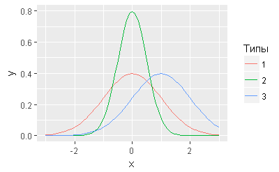

```r
set.seed(1) # правило хорошего тона: установить seed при работе со случайными величинами
library(dplyr)
library(ggplot2) # графика
library(latex2exp)
x <- seq(-3,3,0.1)
df_0_1 <- data.frame(x = x, y = dnorm(x, mean =0, sd = 1), type = 1)
df_0_0.5 <- data.frame(x = x, y = dnorm(x, mean = 0, sd = 0.5), type = 2)
df_1_1 <- data.frame(x = x, y = dnorm(x, mean = 1, sd = 1), type = 3)
df <- bind_rows(df_0_1, df_0_0.5, df_1_1)
df$type <- as.factor(df$type)
ggplot(data = df, aes(x = x, y = y, group = type, colour = type)) +
  geom_line() +
  xlim(-3,3) +
  ggtitle(data.frame(x = x, y = dnorm(x)))+
  xlab("x") +
  ylab("y") +
  scale_colour_discrete(name = "Типы",
                   labels = c(TeX("$ \\mu = 0,  \\sigma = 1$"),
                              TeX("$ \\mu = 0, \\sigma = 0.5$"),
                              TeX("$ \\mu = 0, \\sigma = 1$")))
```

С высоким шансом случайная величина принимает значения, близкие к центру, и наоборот. Нормальное распределение зависит от двух параметров — **матожидания** $\mu$ (отвечает за смещение по оси x) и стандартного отклонения $\sigma$ (отвечает за разброс — чем меньше, тем более сжат график).

# Сама симуляция

Мы проведём $k = 500$ симуляций для базовых значений параметров.

```r
set.seed(1)
k <- 500
N <- 50
a <- 20
c <- 5
d <- 1
sigma_eps <- 1
sigma_v <- 0.5
df <- data.frame(epsilon =
                   rnorm(k,0, sigma_eps))
for(j in 1:N){
    df <- cbind(df,rnorm(k,0, sigma_v))
}
```